# RIP pandas, welcome Polars

[figure not shown]

Marie-Hélène Burle

April 7, 2026

## Goal of this webinar

There is a new and much better library for Python DataFrames

There are no downsides to using it, besides the effort of changing habits. For new users who don’t have habits yet, there are just no downsides

Yet, most Python intro courses still teach the old tool

In this webinar, I will not teach Polars and its syntax. Instead I will demo why it is better

My goal is to help shift the culture towards a wider adoption of Polars

## A brief history of DataFrames

[figure not shown]

## Overview

| Available for | Python |  | Rust, Python, R, NodeJS |
| --- | --- | --- | --- |
| Written in | Cython |  | Rust |
| Multithreading | Some operations |  | Yes (GIL released) |
| Index | Rows are indexed |  | Integer positions are used |
| Evaluation | Eager |  | Eager and lazy |
| Query optimizer | No |  | Yes |
| Out-of-core | No |  | Yes |
| [SIMD](https://en.wikipedia.org/wiki/Single_instruction,_multiple_data) vectorization | Yes |  | Yes |
| Data in memory | [NumPy](https://github.com/numpy/numpy) arrays |  | [Apache Arrow](https://github.com/apache/arrow) arrays |
| Memory efficiency | Poor |  | Excellent |
| Missing data handling | Inconsistent |  | Consistent; type stability |

## Overview

| Available for | Python |  | Rust, Python, R, NodeJS |
| --- | --- | --- | --- |
| Written in | Cython |  | Rust |
| Multithreading | Some operations |  | Yes (GIL released) |
| Index | Rows are indexed |  | Integer positions are used |
| Evaluation | Eager |  | Eager and lazy |
| Query optimizer | No |  | Yes |
| Out-of-core | No |  | Yes |
| [SIMD](https://en.wikipedia.org/wiki/Single_instruction,_multiple_data) vectorization | Yes |  | Yes |
| Data in memory | [NumPy](https://github.com/numpy/numpy) arrays |  | Apache Arrow arrays |
| Memory efficiency | Poor |  | Excellent |
| Missing data handling | Inconsistent |  | Consistent; type stability |

# Missing data

[figure not shown]

For historical reasons, depending on dtype, missing values are one of:

- `NaN` (`numpy.nan`, dtype float)
- `None`
- `NaT` (Not-a-Time, dtype datetime)
- `pandas.NA` (nullable scalar)

This leads to inconsistent behaviour and unexpected dtype changes

[Ongoing open issue since 2020](https://github.com/pandas-dev/pandas/issues/32265)

[figure not shown]

One single value for missing data: `null` (dtype `polars.Null`)

Simple and consistent behaviour across all data types and better performance

`NaN` exists and is a float. It is **not** missing data, but the result of mathematical operations that don’t return numbers

[Here](https://www.dontusethiscode.com/blog/2025-01-22_null_vs_nan_applied.html) is a blog that goes into this in detail

# Group by

[Here](https://labs.quansight.org/blog/dataframe-group-by) is a great blog post by Marco Gorelli comparing the ease of use of passing expressions to groups in Polars compared to pandas

I am using his code here and doing some timing on it to look at efficiency

## Create DataFrames

Import libraries:

```python
import pandas as pd
import polars as pl
```

The pandas DataFrame:

```python
df_pd = pd.DataFrame(
    {
        'id': [1, 1, 1, 2, 2, 2],
        'sales': [4, 1, 2, 7, 6, 7],
        'views': [3, 1, 2, 8, 6, 7]
    }
)
```

The Polars equivalent:

```python
df_pl = pl.DataFrame(
    {
        'id': [1, 1, 1, 2, 2, 2],
        'sales': [4, 1, 2, 7, 6, 7],
        'views': [3, 1, 2, 8, 6, 7]
    }
)
```

The pandas DataFrame:

```python
df_pd
```

|  | id | sales | views |
| --- | --- | --- | --- |
| 0 | 1 | 4 | 3 |
| 1 | 1 | 1 | 1 |
| 2 | 1 | 2 | 2 |
| 3 | 2 | 7 | 8 |
| 4 | 2 | 6 | 6 |
| 5 | 2 | 7 | 7 |

The Polars equivalent:

```python
df_pl
```

shape: (6, 3)

| id i64 | sales i64 | views i64 |
| --- | --- | --- |
| 1 | 4 | 3 |
| 1 | 1 | 1 |
| 1 | 2 | 2 |
| 2 | 7 | 8 |
| 2 | 6 | 6 |
| 2 | 7 | 7 |

## Marco Gorelli’s example

For simple group by operations, both libraries have an easy syntax. Where it gets interesting is for more complex ones such as:

> Find the maximum value of `views`, where `sales` is greater than its mean, per `id`

## Solutions in pandas

The straightforward method involves an anonymous function passed to `apply`:

```python
df_pd.groupby('id').apply(
    lambda df_pd: df_pd[df_pd['sales'] > df_pd['sales'].mean()]['views'].max()
)
```

```
id
1    3
2    8
dtype: int64
```

## Solutions in pandas

Another option, quite tortuous and requiring 2 `groupby` expressions:

```python
df_pd[
    df_pd['sales'] > df_pd.groupby('id')['sales'].transform('mean')
].groupby('id')['views'].max()
```

```
id
1    3
2    8
Name: views, dtype: int64
```

## Solutions in pandas

A third solution involving masks:

```python
gb = df_pd.groupby('id')
mask = df_pd['sales'] > gb['sales'].transform('mean')
df_pd['result'] = df_pd['views'].where(mask)
gb['result'].max()
```

```
id
1    3.0
2    8.0
Name: result, dtype: float64
```

## The solution in Polars

```python
df_pl.group_by('id').agg(
    pl.col('views').filter(pl.col('sales') > pl.mean('sales')).max()
)
```

shape: (2, 2)

| id i64 | views i64 |
| --- | --- |
| 2 | 8 |
| 1 | 3 |

A lot easier to wrap one’s head around …

## Timing of pandas solutions

```python
%%timeit

df_pd.groupby('id').apply(
    lambda df_pd: df_pd[df_pd['sales'] > df_pd['sales'].mean()]['views'].max()
)
```

```
1.04 ms ± 1.33 μs per loop (mean ± std. dev. of 7 runs, 1,000 loops each)
```

The solution most people are likely to use is by far the slowest

## Timing of pandas solutions

```python
%%timeit

df_pd[
    df_pd['sales'] > df_pd.groupby('id')['sales'].transform('mean')
].groupby('id')['views'].max()
```

```
678 μs ± 4.04 μs per loop (mean ± std. dev. of 7 runs, 1,000 loops each)
```

The best solution is the tortuous one with 2 `groupby` expressions

## Timing of pandas solutions

```python
%%timeit

gb = df_pd.groupby('id')
mask = df_pd['sales'] > gb['sales'].transform('mean')
df_pd['result'] = df_pd['views'].where(mask)
gb['result'].max()
```

```
711 μs ± 952 ns per loop (mean ± std. dev. of 7 runs, 1,000 loops each)
```

Masking is almost as fast as the best solution

## Timing of the Polars solution

```python
%%timeit

df_pl.group_by('id').agg(
    pl.col('views').filter(pl.col('sales') > pl.mean('sales')).max()
)
```

```
110 μs ± 3.6 μs per loop (mean ± std. dev. of 7 runs, 10,000 loops each)
```

In addition to being more straightforward, Polars is also much faster

## Conclusion

Speedup of Polars compared to the best pandas method: **6**  
Compared to the method most people are likely to use: **9**

To pass expressions to groups, Polars has a more straightforward and efficient syntax

# General performance comparisons

## A note on my comparisons

The performance of tools can only be evaluated on optimized code: poorly written pandas code is a lot slower than efficient pandas code

To ensure fairness towards pandas, I use the best pandas code from [Alex Razoumov pandas course](https://wgpages.netlify.app/python2/python-13-pandas/) in which he benchmarks various syntaxes

## Example 1: FizzBuzz

[FizzBuzz](https://en.wikipedia.org/wiki/Fizz_buzz#Programming) is a programming exercise based on a children’s game which consists of counting to `n`, replacing:

- any number divisible by `3` with `Fizz`
- any number divisible by `5` with `Buzz`
- any number divisible by both `3` and `5` with `FizzBuzz`

Let’s do it:

```python
# Load additional library
import numpy as np

# Set series length
n = 10_000
```

## Code

[figure not shown]

```python
df_pd = pd.DataFrame()

df_pd['Count'] = np.arange(1, n+1)

df_pd['FizzBuzz'] = df_pd['Count'].astype(str)

df_pd.loc[df_pd['Count'] % 3 == 0, 'FizzBuzz'] = 'Fizz'
df_pd.loc[df_pd['Count'] % 5 == 0, 'FizzBuzz'] = 'Buzz'
df_pd.loc[df_pd['Count'] % 15 == 0, 'FizzBuzz'] = 'FizzBuzz'
```

[figure not shown]

```python
df_pl = pl.DataFrame({'Count': np.arange(1, n+1)})

df_pl.with_columns(pl.col('Count').cast(pl.String).alias('FizzBuzz'))

df_pl = df_pl.with_columns(
    pl.when(pl.col('Count') % 3 == 0).then(pl.lit('Fizz'))
    .when(pl.col('Count') % 5 == 0).then(pl.lit('Buzz'))
    .when(pl.col('Count') % 15 == 0).then(pl.lit('FizzBuzz'))
    .otherwise(pl.col('Count')).alias('FizzBuzz')
)
```

## Lazy evaluation

But it gets much better with lazy evaluation

First, we create a LazyFrame instead of a DataFrame. The query is not evaluated but a graph is created. This allows the query optimizer to fuse operations and perform [optimizations](https://docs.pola.rs/user-guide/lazy/optimizations/) where possible the way compilers do

To evaluate the query and get a result, we use the `collect` method

[figure not shown]

```python
# Lazy API

df_pl_lazy = pl.LazyFrame({'Count': np.arange(1, n+1)})

df_pl_lazy.with_columns(pl.col('Count').cast(pl.String).alias('FizzBuzz'))

df_pl_lazy = df_pl_lazy.with_columns(
    pl.when(pl.col('Count') % 3 == 0).then(pl.lit('Fizz'))
    .when(pl.col('Count') % 5 == 0).then(pl.lit('Buzz'))
    .when(pl.col('Count') % 15 == 0).then(pl.lit('FizzBuzz'))
    .otherwise(pl.col('Count')).alias('FizzBuzz')
)

df_pl_lazy_collected = df_pl_lazy.collect()
```

## Results

```python
df_pd.head()   # pandas
```

|  | Count | FizzBuzz |
| --- | --- | --- |
| 0 | 1 | 1 |
| 1 | 2 | 2 |
| 2 | 3 | Fizz |
| 3 | 4 | 4 |
| 4 | 5 | Buzz |

```python
df_pl.head()
# same for df_pl_lazy_collected
```

shape: (5, 2)

| Count i64 | FizzBuzz str |
| --- | --- |
| 1 | "1" |
| 2 | "2" |
| 3 | "Fizz" |
| 4 | "4" |
| 5 | "Buzz" |

## Timing

[figure not shown]

```python
%%timeit

df_pd = pd.DataFrame()

df_pd['Count'] = np.arange(1, n+1)

df_pd['FizzBuzz'] = df_pd['Count'].astype(str)

df_pd.loc[df_pd['Count'] % 3 == 0, 'FizzBuzz'] = 'Fizz'
df_pd.loc[df_pd['Count'] % 5 == 0, 'FizzBuzz'] = 'Buzz'
df_pd.loc[df_pd['Count'] % 15 == 0, 'FizzBuzz'] = 'FizzBuzz'
```

```
3.4 ms ± 65.4 μs per loop (mean ± std. dev. of 7 runs, 100 loops each)
```

[figure not shown]

```python
%%timeit

df_pl = pl.DataFrame({'Count': np.arange(1, n+1)})

df_pl.with_columns(pl.col('Count').cast(pl.String).alias('FizzBuzz'))

df_pl.with_columns(
    pl.when(pl.col('Count') % 3 == 0).then(pl.lit('Fizz'))
    .when(pl.col('Count') % 5 == 0).then(pl.lit('Buzz'))
    .when(pl.col('Count') % 15 == 0).then(pl.lit('FizzBuzz'))
    .otherwise(pl.col('Count')).alias('FizzBuzz')
)
```

```
648 μs ± 2.21 μs per loop (mean ± std. dev. of 7 runs, 1,000 loops each)
```

[figure not shown]

```python
%%timeit

# Lazy API

df_pl_lazy = pl.LazyFrame({'Count': np.arange(1, n+1)})

df_pl_lazy.with_columns(pl.col('Count').cast(pl.String).alias('FizzBuzz'))

df_pl_lazy = df_pl_lazy.with_columns(
    pl.when(pl.col('Count') % 3 == 0).then(pl.lit('Fizz'))
    .when(pl.col('Count') % 5 == 0).then(pl.lit('Buzz'))
    .when(pl.col('Count') % 15 == 0).then(pl.lit('FizzBuzz'))
    .otherwise(pl.col('Count')).alias('FizzBuzz')
)

df_pl = df_pl_lazy.collect()
```

```
462 μs ± 4.05 μs per loop (mean ± std. dev. of 7 runs, 1,000 loops each)
```

## Speedup

Speedup with Polars DataFrame: **5**  
With Polars LazyFrame: **7**

These speedups highly depend on the types and sizes of the problems

How much faster Polars is does vary, what doesn’t vary is that it is always much faster

## Memory usage

**pandas**

```python
df_pd.memory_usage()
```

```
Index          132
Count        80000
FizzBuzz    122073
dtype: int64
```

**Polars**

```python
df_pl.estimated_size()
```

```
119409
```

119,409 bytes  
**≈ 119 KB**

**Polars lazy API**

Same as Polars eager:  
if you collect the entire DataFrame as we did here, the lazy API does not reduce the memory footprint

## Example 2: medium dataset

Here I am using [a jeopardy dataset](https://raw.githubusercontent.com/razoumov/publish/master/jeopardy.csv) that Alex uses in his pandas course

Shape: 216,930 rows, 7 columns

The goal is to subset this DataFrame for the history category and get the shape of the resulting DataFrame

## Code

[figure not shown]

```python
df_pd = pd.read_csv(
    'https://raw.githubusercontent.com/razoumov/publish/master/jeopardy.csv'
)

df_pd_subset = df_pd.loc[df_pd['Category'] == 'HISTORY']

df_pd_subset.shape
```

```
(349, 7)
```

[figure not shown]

```python
df_pl = pl.read_csv(
    'https://raw.githubusercontent.com/razoumov/publish/master/jeopardy.csv'
)

df_pl_subset = df_pl.filter(pl.col('Category') == 'HISTORY')

df_pl_subset.shape
```

```
(349, 7)
```

[figure not shown]

```python
# Lazy API

df_pl_lazy = pl.scan_csv(
    'https://raw.githubusercontent.com/razoumov/publish/master/jeopardy.csv'
)

df_pl_lazy_subset_collected = df_pl_lazy.filter(
    pl.col('Category') == 'HISTORY'
).collect()

df_pl_lazy_subset_collected.shape
```

```
(349, 7)
```

## Timing

[figure not shown]

```python
%%timeit

df_pd = pd.read_csv(
    'https://raw.githubusercontent.com/razoumov/publish/master/jeopardy.csv'
)

df_pd.loc[df_pd['Category'] == 'HISTORY'].shape
```

```
1.17 s ± 5.2 ms per loop (mean ± std. dev. of 7 runs, 1 loop each)
```

[figure not shown]

```python
%%timeit

df_pl = pl.read_csv(
    'https://raw.githubusercontent.com/razoumov/publish/master/jeopardy.csv'
)

df_pl.filter(pl.col('Category') == 'HISTORY').shape
```

```
778 ms ± 30.5 ms per loop (mean ± std. dev. of 7 runs, 1 loop each)
```

[figure not shown]

```python
%%timeit

# Lazy API

df_pl_lazy = pl.scan_csv(
    'https://raw.githubusercontent.com/razoumov/publish/master/jeopardy.csv'
)

df_pl_lazy.filter(pl.col('Category') == 'HISTORY').collect().shape
```

```
67.7 ms ± 3.87 ms per loop (mean ± std. dev. of 7 runs, 10 loops each)
```

## Speedup

Polars here brings a speedup of **1.5**

The lazy API ramps that up to a speedup of **17**

## Memory usage

**pandas**

```python
df_pd.memory_usage()
```

```
Index               132
Show Number     1735440
Air Date        3257131
Round           4450983
Category        5001930
Value           2951677
Question       20444115
Answer          4271534
dtype: int64
```

**Polars**

```python
df_pl.estimated_size()
```

```
31606250
```

31,606,250 bytes  
**≈ 31 MB**

**Polars lazy API**

```python
df_pl_lazy_subset_collected.estimated_size()
```

```
48774
```

48,774 bytes  
**≈ 49 KB**

If you only collect a subset of the data, the memory footprint drops dramatically

# Data too big to fit in memory

## Example of large dataset

Let’s play with data from the [GBIF](https://www.gbif.org/) website (free and open access biodiversity database)

The [Southern African Bird Atlas Project 2](https://www.gbif.org/dataset/906e6978-e292-4a8b-9c39-adf6bb0f3323) [1] contains a raw CSV file of 42 GB and an interpreted CSV file of 12.3 GB. Let’s look at the latter:

Shape: 25,687,526 rows, 50 columns

From that dataset, I want a list of species from the genus *Passer* (Old World sparrows)

## Side note: the importance of file format

Text-based formats (CSV, JSON) are not suitable for large files

[Apache Parquet](https://parquet.apache.org/) is a binary, machine-optimized, column-oriented file format with efficient encoding and compression and it is considered the industry-standard file format for large tabular data

|  |  |  | File type |  |  | Size |
| --- | --- | --- | --- | --- | --- | --- |
| File downloaded from GBIF |  |  | Zipped CSV |  |  | 2.2 GB |
| Uncompressed file |  |  | CSV |  |  | 12.3 GB |
| Ideal file format |  |  | Parquet |  |  | 0.5 GB |

## Format conversion

Here is a way to convert this file if it fits in memory:

```python
# Read in the CSV file in a Polars DataFrame
df = pl.read_csv('sa_birds.csv', separator='\t')

# Export the DataFrame in a Parquet file
df.write_parquet('sa_birds.parquet')
```

## Native Apache Arrow support

With its native support for the columnar Apache Arrow format, Polars is ideal to work with Parquet files

pandas can work with Parquet files but this can lead to issues due to the inconsistent way it handles missing data (e.g. see [this SO question](https://stackoverflow.com/q/54866522/9210961), [this issue](https://github.com/pandas-dev/pandas/issues/55721), this post)

```python
%%timeit

# pandas
sa_birds_pd = pd.read_parquet(
    'sa_birds.parquet'
)
```

```
1min 10s ± 7.76 s per loop (mean ± std. dev. of 7 runs, 1 loop each)
```

```python
%%timeit

# Polars
sa_birds_pl = pl.read_parquet(
    'sa_birds.parquet'
)
```

```
2.47 s ± 756 ms per loop (mean ± std. dev. of 7 runs, 1 loop each)
```

Speedup: 70 / 2.47 ≈ **28** Reading Parquet files in pandas is also A LOT slower!

## RAM required

**pandas**

```python
sa_birds_pd.memory_usage()
```

```
Index                          132
gbifID                   205500208
datasetKey               205500208
occurrenceID             205500208
kingdom                  205500208
phylum                   205500208
class                    205500208
order                    205500208
...
dtype: int64
```

132 + 205,500,208 * 50 =  
10,275,010,532 bytes  
**≈ 10 GB**

**Polars**

```python
sa_birds_pl.estimated_size()
```

```
12291023880
```

12,291,023,880 bytes  
**≈ 12 GB**

## RAM required

Let’s imagine that you have only 16 GB of RAM on your machine

Running a browser and a few small applications take about 6 GB out of that. This dataset is already too big to process on your laptop

If you need to play with the raw data or a larger dataset such as the [eBird dataset](https://www.gbif.org/dataset/4fa7b334-ce0d-4e88-aaae-2e0c138d049e) of 1,775,781,186 rows and 50 columns (**CSV file of 3 TB for the raw data**), you will need A LOT of memory

## What are your options?

In pandas or Polars:

- Read in data only for the columns you are interested in
- Read and process the file in chunks and try to combine the results

If you only need to run queries on the data however, the Polars lazy API is the answer

## Create a LazyFrame

You can create a LazyFrame (no impact on memory, LazyFrame returned instantly):

```python
df_pl_lazy = pl.scan_parquet('sa_birds.parquet')
```

Run a query on it (no impact on memory, LazyFrame returned instantly):

```python
passer_df_lazy = df_pl_lazy.filter(
    pl.col('genus') == 'Passer'
).select(pl.col('species')).unique()
```

## Collect the result

Now, you collect the result (this uses memory and takes time to compute) and turn the DataFrame into a Python list:

```python
passer_ls = passer_df_lazy.collect().get_column('species').to_list()
```

Depending on the subset returned by your query, the memory usage will vary. Here, the collected result is minuscule (79 bytes):

```python
passer_df_lazy.collect().estimated_size()
```

```
79
```

You need more than that to actually run the code, but not that much more (see later)

## Et voilà

```python
print(passer_ls)
```

```
['Passer motitensis', 'Passer domesticus', 'Passer griseus', 'Passer diffusus', 'Passer melanurus']
```

With this method, as long as the data itself fits on a drive and the queries don’t return huge subsets of data, you can run queries on giant datasets such as the 3 TB [eBird dataset](https://www.gbif.org/dataset/4fa7b334-ce0d-4e88-aaae-2e0c138d049e) with a very small amount of RAM

Note that the queries can contain complex expressions. What matters is the size of the subset you need to collect at the end

## How much RAM is actually needed?

I did a little experiment on a cluster:

I ran the previous code on a single CPU core and gradually reduced the amount of memory asked from Slurm until I got an OOM error

I got the result with as little as 150 MB of memory

*Remember that this DataFrame would require 10 GB of RAM just to be read in pandas, not counting for any computation*

## Conclusion

Polars:

- Handles missing data in a consistent and sensible way
- Has a clear syntax
- Allows passing expressions to group by in a convenient way
- Is very fast
- Uses multithreading automatically
- Is extremely memory efficient with the lazy API
- Uses the industry standard Apache Arrow columnar format
- Works perfectly with Parquet files
- Works out-of-core with the lazy API

## Conclusion

**Start using Polars now!**

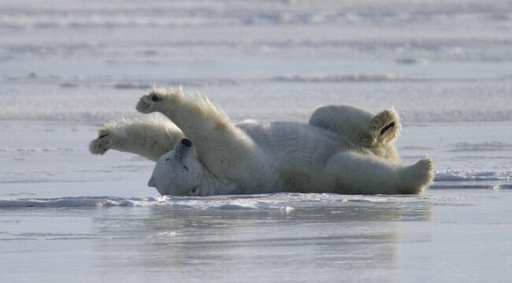

**And use the lazy API!**

**Reference**

1.

GBIF.org (2026) [Occurrence download](https://doi.org/10.15468/DL.GQWNM2)